# Analysis of results

Adrien KEREBEL

17 juin 2019

```r
# Import libraries
library("ggplot2")
library("dplyr")
#Parameter for graphs:
dodge = position_dodge(width = 0.9)
```

# **Prepare dataset**

### Load data

Nine participants completed the experiment (3 females, 6 males, mean age = 26.7, stdev age = 13.0). Their musical backgrounds ranged from medium (4 years of piano lessons) to strong (+10 years of practice).

```r
donnees1 <- read.table("data/experiment_spectral_pitch_final_v2_01_201905141633.xpd", sep = ",", header = TRUE, skip = 34, stringsAsFactors=FALSE)
donnees2 <- read.table("data/experiment_spectral_pitch_final_v2_02_201905161605.xpd", sep = ",", header = TRUE, skip = 34, stringsAsFactors=FALSE)
donnees3 <- read.table("data/experiment_spectral_pitch_final_v2_03_201905181448.xpd", sep = ",", header = TRUE, skip = 34, stringsAsFactors=FALSE)
donnees4 <- read.table("data/experiment_spectral_pitch_final_v2_04_201905181546.xpd", sep = ",", header = TRUE, skip = 34, stringsAsFactors=FALSE)
donnees5 <- read.table("data/experiment_spectral_pitch_final_v2_05_201905181625.xpd", sep = ",", header = TRUE, skip = 34, stringsAsFactors=FALSE)
donnees6 <- read.table("data/experiment_spectral_pitch_final_v2_06_201905181658.xpd", sep = ",", header = TRUE, skip = 34, stringsAsFactors=FALSE)
donnees7 <- read.table("data/experiment_spectral_pitch_final_v2_07_201905182240.xpd", sep = ",", header = TRUE, skip = 34, stringsAsFactors=FALSE)
donnees8 <- read.table("data/experiment_spectral_pitch_final_v2_08_201905182334.xpd", sep = ",", header = TRUE, skip = 34, stringsAsFactors=FALSE)
donnees9 <- read.table("data/experiment_spectral_pitch_final_v2_09_201905201240.xpd", sep = ",", header = TRUE, skip = 34, stringsAsFactors=FALSE)
donnees <- rbind(donnees1,donnees2,donnees3,donnees4,donnees5,donnees6,donnees7,donnees8,donnees9)

nb_participants <- 9
```

### Specify factors

```r
donnees$comparaison <- factor(donnees$comparaison,
                              levels = 1:4)
donnees$zone_fc <- factor(donnees$zone_fc,
                     levels = 1:3)
donnees$ordre <- factor(donnees$ordre,
                        levels = 1:2)
donnees$f0 <- factor(donnees$f0,
                     levels = 1:2)
```

### Split into training phase and test phase

```r
donnees_entrainement = subset(donnees, donnees$Entrainement_ou_test == 'entrainement')
donnees_test = subset(donnees, donnees$Entrainement_ou_test == 'test')
```

# **Analysis**

## Pitch discrimination test phase

```r
donnees_entrainement$Response_entrainement <- as.logical(donnees_entrainement$Response_entrainement)
score_entrainement = mean(donnees_entrainement$Response_entrainement)*100
```

The mean accuracy score on the pitch discrimination phase is: 97.6851852% This result shows that participants are able to hear the differences between the pitches predicted by the two models (at least with pure tones).

The discrimination task is supposed to be more difficult in high harmonic zones:

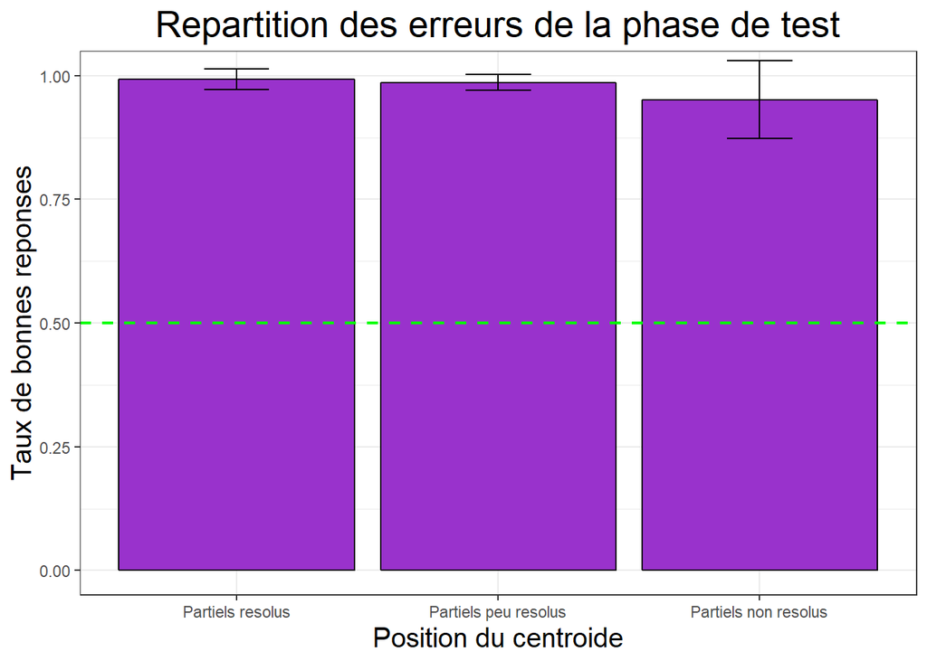

```r
resXzone_ALL = aggregate(Response_entrainement ~ zone_fc  + subject_id, data = donnees_entrainement, mean)
resXzone_SE = aggregate(Response_entrainement ~ zone_fc, data = resXzone_ALL, sd)
resXzone = aggregate(Response_entrainement ~ zone_fc, data = resXzone_ALL, mean)
resXzone$SE = resXzone_SE$Response_entrainement
errorBarsres = aes(ymax = Response_entrainement + SE, ymin = Response_entrainement - SE)

resXzone_PLOT =ggplot(data = resXzone, aes(x= zone_fc, y = Response_entrainement)) +
  geom_bar(position = dodge, stat = "identity", color="black", fill="darkorchid")+
  scale_x_discrete(labels = c("Partiels resolus", "Partiels peu resolus", "Partiels non resolus")) +
  geom_errorbar(errorBarsres, position= dodge, width = 0.25) +
  geom_hline(yintercept=0.5, linetype="dashed",
             color = "green", size=0.8) +
  scale_y_continuous("Taux de bonnes reponses")+
  theme_bw() +
  xlab("Position du centroide") +
  ggtitle("Repartition des erreurs de la phase de test")+
  theme(plot.title = element_text(hjust = 0.5, size = 20)) +
  theme(axis.title.x = element_text(size = 15)) +
  theme(axis.title.y = element_text(size = 15)) +
  coord_cartesian(ylim = c(0,1))+
  guides(fill=FALSE)
resXzone_PLOT
```

```r
t = table(donnees_entrainement$zone_fc , donnees_entrainement$Response_entrainement)
chisq.test(t)
```

```
##
##  Pearson's Chi-squared test
##
## data:  t
## X-squared = 12.694, df = 2, p-value = 0.001752
```

The discrimination accuracy is indeed to be slightly lower on the highest harmonic zone.

## Task phase

```r
# Highlighting the times when the second model (strongest partial, "strair like") was prefered
escalier_choisi <- c(((donnees_test$ordre == 1) & (donnees_test$Response_test == 'first_best')) | ((donnees_test$ordre == 2) & (donnees_test$Response_test == 'second_best')))

donnees_test <- cbind(donnees_test, escalier_choisi)
```

### Is their an effect of the zone ?

*Remark*: It is not clear what choosing the prediction of one model or the other when the spectral bump is in the middle two harmonics means … (comparisons 1 and 2 on the README document, section “Task”)

Let’s focus on comparisons 3 and 4 for now (at f_z-(f0/4) and f_z+(f0/4)):

```r
data_comp_3_4 <- subset(donnees_test, (comparaison == 3 | comparaison == 4))
```

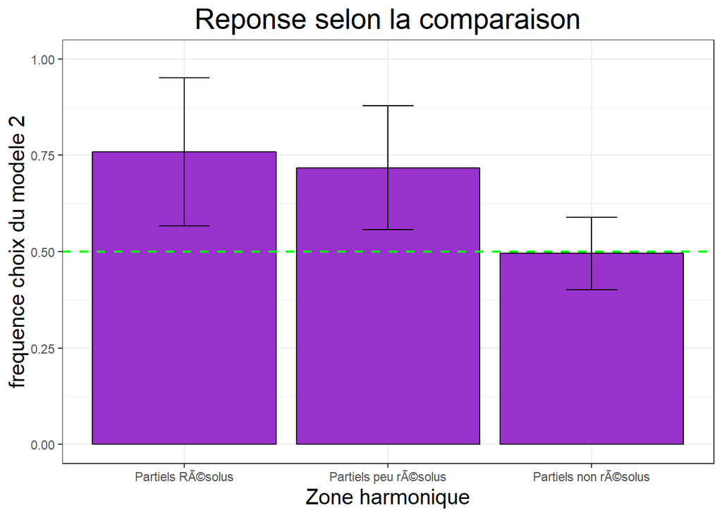

```r
errorBarsesc = aes(ymax = escalier_choisi + SE, ymin = escalier_choisi - SE)
choix_escXzone_fc_ALL = aggregate(escalier_choisi ~ zone_fc  + subject_id, data = data_comp_3_4, mean)
choix_escXzone_fc_sd = aggregate(escalier_choisi ~ zone_fc, data = choix_escXzone_fc_ALL, sd)
choix_escXzone_fc = aggregate(escalier_choisi ~ zone_fc, data = choix_escXzone_fc_ALL, mean)

choix_escXzone_fc$SE = choix_escXzone_fc_sd$escalier_choisi

choix_escXzone_fc_PLOT =ggplot(data = choix_escXzone_fc, aes(x= zone_fc, y = escalier_choisi)) +
  geom_bar(position = dodge, stat = "identity", color="black", fill="darkorchid")+
  geom_errorbar(errorBarsesc, position= dodge, width = 0.25) +
  scale_x_discrete(labels = c("Partiels RÃ©solus", "Partiels peu rÃ©solus", "Partiels non rÃ©solus")) +
  geom_hline(yintercept=0.5, linetype="dashed",
             color = "green", size=0.8) +
  scale_y_continuous("frequence choix du modele 2")+
  theme_bw() +
  xlab("Zone harmonique") +
  ggtitle("Reponse selon la comparaison")+
  theme(plot.title = element_text(hjust = 0.5, size = 20)) +
  theme(axis.title.x = element_text(size = 15)) +
  theme(axis.title.y = element_text(size = 15)) +
  coord_cartesian(ylim = c(0,1))+
  guides(fill=FALSE)
choix_escXzone_fc_PLOT
```

##### Statistical comparisons

- Test of the normality of the differences

```r
with(choix_escXzone_fc_ALL, tapply(X = escalier_choisi,INDEX = zone_fc,FUN = shapiro.test))
```

```
## $`1`
##
##  Shapiro-Wilk normality test
##
## data:  X[[i]]
## W = 0.86067, p-value = 0.0975
##
##
## $`2`
##
##  Shapiro-Wilk normality test
##
## data:  X[[i]]
## W = 0.93129, p-value = 0.4937
##
##
## $`3`
##
##  Shapiro-Wilk normality test
##
## data:  X[[i]]
## W = 0.91223, p-value = 0.3318
```

- Check homogeneity of variances

```r
aggregate(escalier_choisi ~ zone_fc  + subject_id, data = data_comp_3_4, sd)[3]^2
```

```
##    escalier_choisi
## 1       0.17210145
## 2       0.19565217
## 3       0.23188406
## 4       0.14492754
## 5       0.04166667
## 6       0.26086957
## 7       0.25905797
## 8       0.25905797
## 9       0.25905797
## 10      0.04166667
## 11      0.14492754
## 12      0.24456522
## 13      0.23188406
## 14      0.11413043
## 15      0.25905797
## 16      0.25905797
## 17      0.25905797
## 18      0.24456522
## 19      0.04166667
## 20      0.26086957
## 21      0.26086957
## 22      0.25905797
## 23      0.21557971
## 24      0.25362319
## 25      0.00000000
## 26      0.19565217
## 27      0.25905797
```

- ANOVA

```r
effect_of_zone = aov(escalier_choisi~zone_fc, data = choix_escXzone_fc_ALL)
summary(effect_of_zone)
```

```
##             Df Sum Sq Mean Sq F value  Pr(>F)
## zone_fc      2 0.3623 0.18113   7.588 0.00279 **
## Residuals   24 0.5729 0.02387
## ---
## Signif. codes:  0 '***' 0.001 '**' 0.01 '*' 0.05 '.' 0.1 ' ' 1
```

As expected their is an effect of the harmonic zone on the choice of model.

- Post hoc comparisons

```r
choix_esc_z1 <- subset(choix_escXzone_fc_ALL, (choix_escXzone_fc_ALL$zone_fc == 1))$escalier_choisi
choix_esc_z2 <- subset(choix_escXzone_fc_ALL, (choix_escXzone_fc_ALL$zone_fc == 2))$escalier_choisi
choix_esc_z3 <- subset(choix_escXzone_fc_ALL, (choix_escXzone_fc_ALL$zone_fc == 3))$escalier_choisi

t.test(x = choix_esc_z1, y = choix_esc_z2, paired = TRUE, alternative = "two.sided") # non
```

```
##
##  Paired t-test
##
## data:  choix_esc_z1 and choix_esc_z2
## t = 0.58835, df = 8, p-value = 0.5725
## alternative hypothesis: true difference in means is not equal to 0
## 95 percent confidence interval:
##  -0.1216439  0.2049772
## sample estimates:
## mean of the differences
##              0.04166667
```

```r
t.test(x = choix_esc_z1, y = choix_esc_z3, paired = TRUE, alternative = "greater") # oui
```

```
##
##  Paired t-test
##
## data:  choix_esc_z1 and choix_esc_z3
## t = 3.9618, df = 8, p-value = 0.002083
## alternative hypothesis: true difference in means is greater than 0
## 95 percent confidence interval:
##  0.1400267       Inf
## sample estimates:
## mean of the differences
##               0.2638889
```

```r
t.test(x = choix_esc_z2, y = choix_esc_z3, paired = TRUE, alternative = "greater") # oui
```

```
##
##  Paired t-test
##
## data:  choix_esc_z2 and choix_esc_z3
## t = 3.7712, df = 8, p-value = 0.002728
## alternative hypothesis: true difference in means is greater than 0
## 95 percent confidence interval:
##  0.1126473       Inf
## sample estimates:
## mean of the differences
##               0.2222222
```

There is a significant difference between the proportion of choice of the prediction of the second model between the harmonic zones 1 and 2 (resolved and less resolved partials) and the harmonic zone 3 (unresolved partials).

- Comparison against chance

```r
t.test(x = choix_esc_z1, mu = 0.5)
```

```
##
##  One Sample t-test
##
## data:  choix_esc_z1
## t = 4.0547, df = 8, p-value = 0.00366
## alternative hypothesis: true mean is not equal to 0.5
## 95 percent confidence interval:
##  0.6118114 0.9067072
## sample estimates:
## mean of x
## 0.7592593
```

```r
t.test(x = choix_esc_z2, mu = 0.5)
```

```
##
##  One Sample t-test
##
## data:  choix_esc_z2
## t = 4.0526, df = 8, p-value = 0.003671
## alternative hypothesis: true mean is not equal to 0.5
## 95 percent confidence interval:
##  0.5937792 0.8414059
## sample estimates:
## mean of x
## 0.7175926
```

```r
t.test(x = choix_esc_z3, mu = 0.5)
```

```
##
##  One Sample t-test
##
## data:  choix_esc_z3
## t = -0.14744, df = 8, p-value = 0.8864
## alternative hypothesis: true mean is not equal to 0.5
## 95 percent confidence interval:
##  0.4229626 0.5677782
## sample estimates:
## mean of x
## 0.4953704
```

The second model is chosen more than the other one on the harmonic zones 1 and 2 (resolved and less resolved partials). This confirms my predictions.

On the harmonic zone 3 (unresolved partials), the choice is at the level of chance. This result is more suprising.

We can imagine three explanations:

- It could be that subjects don’t disciminate spectral pitches well at this height, but it is unexpected given the high score at the first phase.
- It could be that half of them chose one model and the other half the other, due to the use of different strategies to complete the task for example. We can check it quickly:

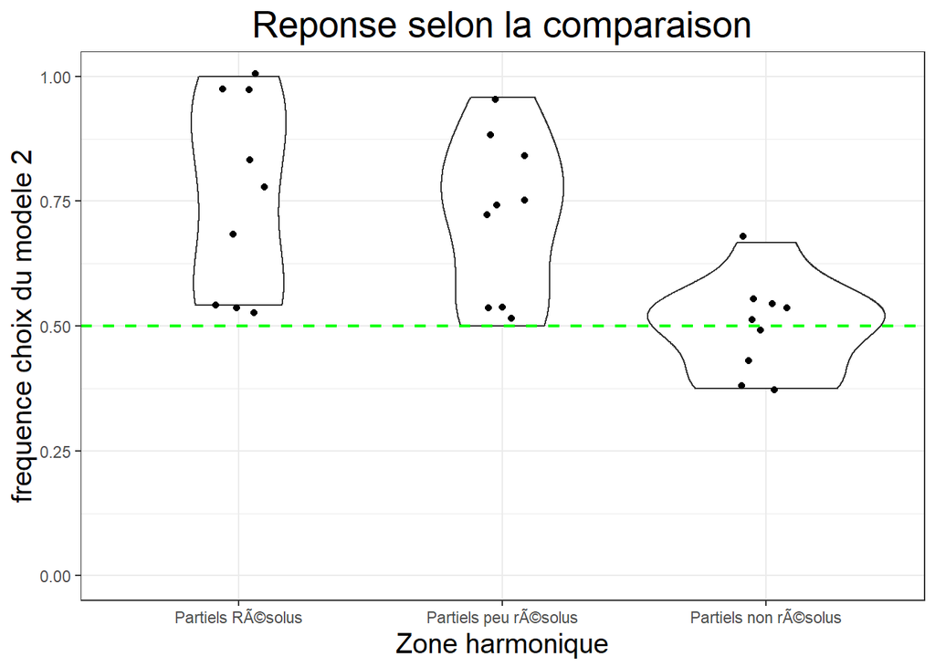

```r
ggplot(data = choix_escXzone_fc_ALL,
       mapping = aes(y = escalier_choisi, x = zone_fc)) +
  geom_violin() +
  geom_jitter(width = .1) +
  geom_hline(yintercept=0.5, linetype="dashed",
             color = "green", size=0.8) +
  scale_x_discrete(labels = c("Partiels RÃ©solus", "Partiels peu rÃ©solus", "Partiels non rÃ©solus")) +
  theme_bw() +
  scale_y_continuous("frequence choix du modele 2")+
  theme_bw() +
  xlab("Zone harmonique") +
  ggtitle("Reponse selon la comparaison")+
  theme(plot.title = element_text(hjust = 0.5, size = 20)) +
  theme(axis.title.x = element_text(size = 15)) +
  theme(axis.title.y = element_text(size = 15)) +
  coord_cartesian(ylim = c(0,1))
```

As we can see it is not the case.

- Another explanation could be that all subjects choose the prediction of one model in one of the two comparisons and the prediction of the other model on the second comparison, ie that there is an interaction between the comparison (f_z-(f0/4) or f_z+(f0/4)) and the harmonic zone.

## Is their an interaction between the comparison and the harmonic zone ?

- ANOVA

```r
choix_escXcomparaisonXzone_ALL = aggregate(escalier_choisi ~ comparaison  + zone_fc + subject_id, data = data_comp_3_4, mean)
inter_comp_zone = aov(escalier_choisi ~ comparaison * zone_fc, data = choix_escXcomparaisonXzone_ALL)
summary(inter_comp_zone)
```

```
##                     Df Sum Sq Mean Sq F value   Pr(>F)
## comparaison          1 0.2963  0.2963   6.837 0.011897 *
## zone_fc              2 0.7245  0.3623   8.359 0.000768 ***
## comparaison:zone_fc  2 0.3387  0.1694   3.908 0.026766 *
## Residuals           48 2.0802  0.0433
## ---
## Signif. codes:  0 '***' 0.001 '**' 0.01 '*' 0.05 '.' 0.1 ' ' 1
```

The interaction is significant.

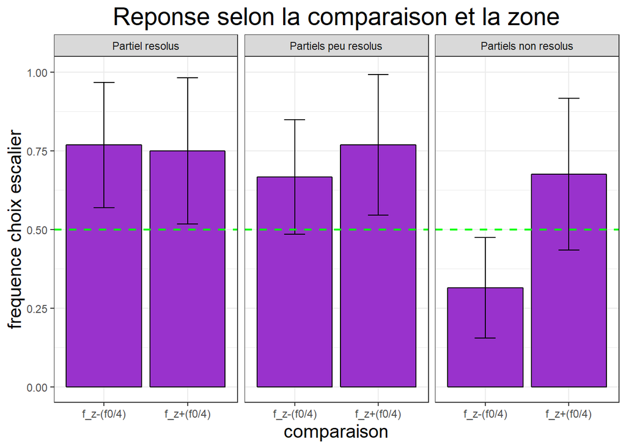

```r
choix_escXcomparaisonXzone_sd = aggregate(escalier_choisi ~ comparaison + zone_fc, data = choix_escXcomparaisonXzone_ALL, sd)
choix_escXcomparaisonXzone = aggregate(escalier_choisi ~ comparaison + zone_fc, data = choix_escXcomparaisonXzone_ALL, mean)
choix_escXcomparaisonXzone$SE = choix_escXcomparaisonXzone_sd$escalier_choisi

zone_names <- list(
  '1'="Partiel resolus",
  '2'="Partiels peu resolus",
  '3'="Partiels non resolus")
zone_labeller <- function(variable,value){
  return(zone_names[value])
}

choix_escXcomparaison_PLOT <- ggplot(data = choix_escXcomparaisonXzone, aes(x= comparaison, y = escalier_choisi)) +
  geom_bar(position = dodge, stat = "identity", color="black", fill="darkorchid")+
  facet_grid(. ~ zone_fc, labeller=zone_labeller) +
  geom_errorbar(errorBarsesc, position= dodge, width = 0.25) +
  geom_hline(yintercept=0.5, linetype="dashed",
             color = "green", size=0.8) +
  scale_y_continuous("frequence choix escalier")+
  theme_bw() +
  scale_x_discrete(labels = c("f_z-(f0/4)", "f_z+(f0/4)"))+
  xlab("comparaison") +
  ggtitle("Reponse selon la comparaison et la zone")+
  theme(plot.title = element_text(hjust = 0.5, size = 20)) +
  theme(axis.title.x = element_text(size = 15)) +
  theme(axis.title.y = element_text(size = 15)) +
  coord_cartesian(ylim = c(0,1))+
  guides(fill=FALSE)
choix_escXcomparaison_PLOT
```

We can see indeed that comparisons at f_z-(f0/4) and at f_z+(f0/4) elicits two different responses. This could be interpreted as a bias towards the lowest pitches in high frequencies.